# Projet tourbière

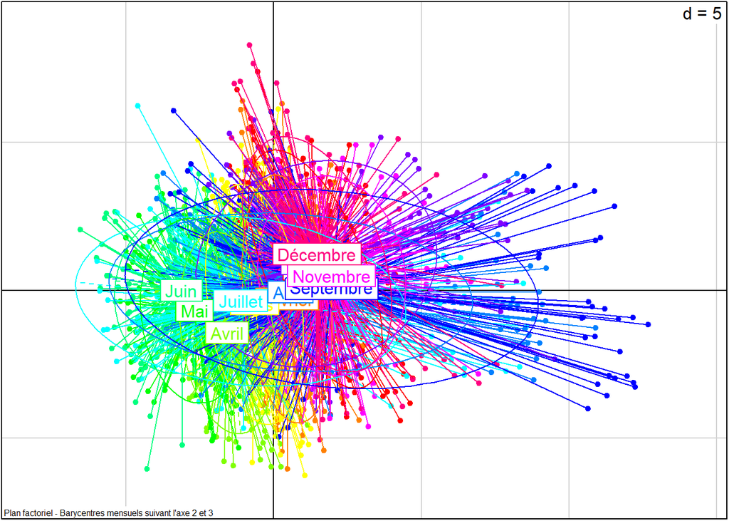

```r
 #  Représentation graphique : groupé par mois
s.class(acp$li[,c(2,3)], fac = mois1, col = rainbow(length(unique(mois))),
        sub = "Plan factoriel - Barycentres mensuels suivant l'axe 2 et 3",
        csub = 0.5)
```

Ici ça ne nous donne pas grandes choses

### Representons le plan factoriel, barycentré sur l’année

```r
an <- format(dates, format = "%Y")
an_fac <- factor(an, ordered = TRUE)
```

#### Suivant l’axe 1 et 2

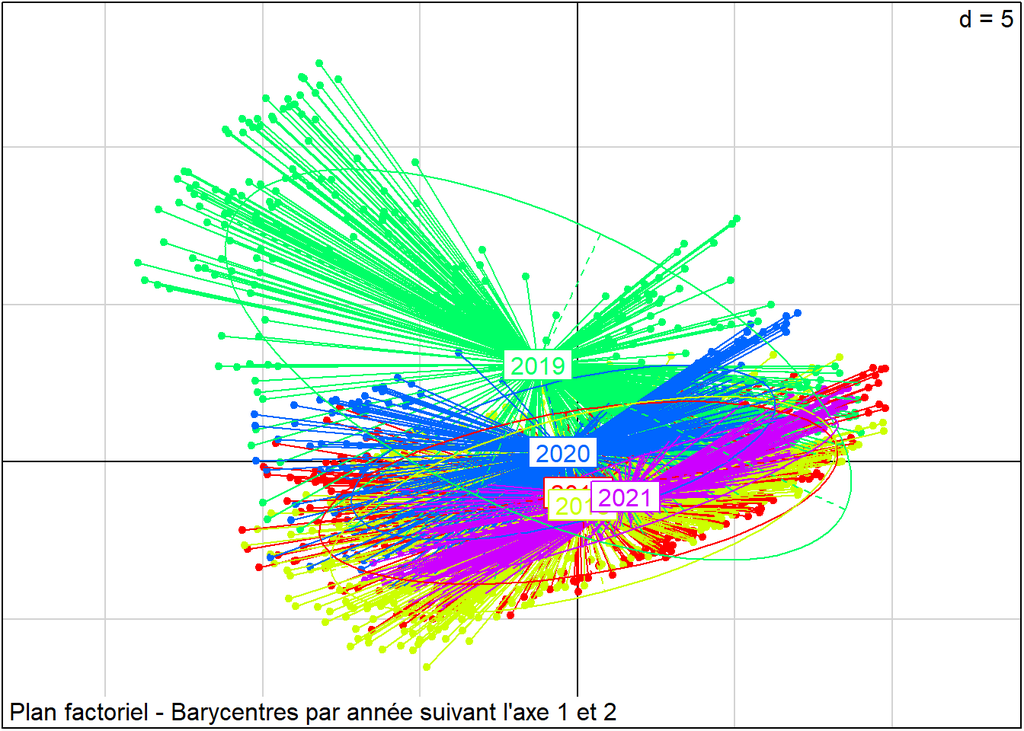

```r
s.class(dfxy = acp$li[, c(1,2)], fac = an_fac, col = rainbow(length(unique(an_fac))),sub = "Plan factoriel - Barycentres par année suivant l'axe 1 et 2 ",csub = 1)
```

Dans ce plan factoriel on observe que l’année 2019 est sépararée des autres années et suivant l’axe 2

#### Suivant l’axe 1 et 3

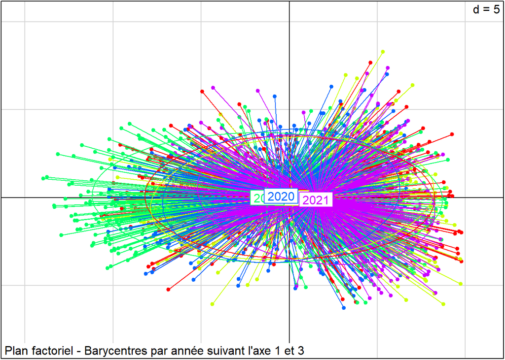

```r
s.class(dfxy = acp$li[, c(1,3)], fac = an_fac, col = rainbow(length(unique(an_fac))),sub = "Plan factoriel - Barycentres par année suivant l'axe 1 et 3 ",csub = 1)
```

ce plan ne nous donne vraiment pas des informations

#### Suivant l’axe 2 et 3

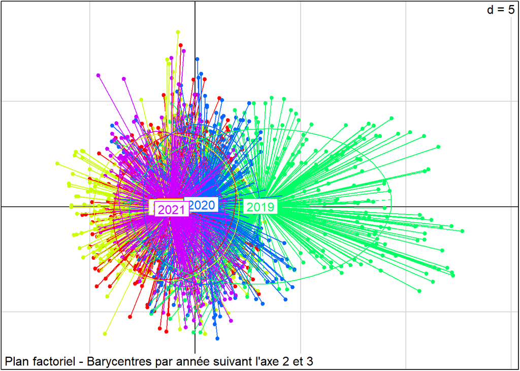

```r
s.class(dfxy = acp$li[, c(2,3)], fac = an_fac, col = rainbow(length(unique(an_fac))),sub = "Plan factoriel - Barycentres par année suivant l'axe 2 et 3 ",csub = 1)
```

Dans le plan factoriel on observe que l’année 2019 est sépararée des autres années et suivant l’axe 2 comme celui du 1er plan .

## 2) Etude des axes factorils comme série temporelle

Pour décomposer les composantes principales ainsi que les séries des gaz à effet de serre en leurs différentes composantes (tendance, saisonnalité et bruit), nous utiliserons la fonction decompose(). Cette fonction calcule notamment la tendance par la méthode des moyennes mobiles, ce qui est particulièrement adapté lorsque les séries sont additives.

##### Pour l’axe factoriel 1

-Tendance et saisonnalité

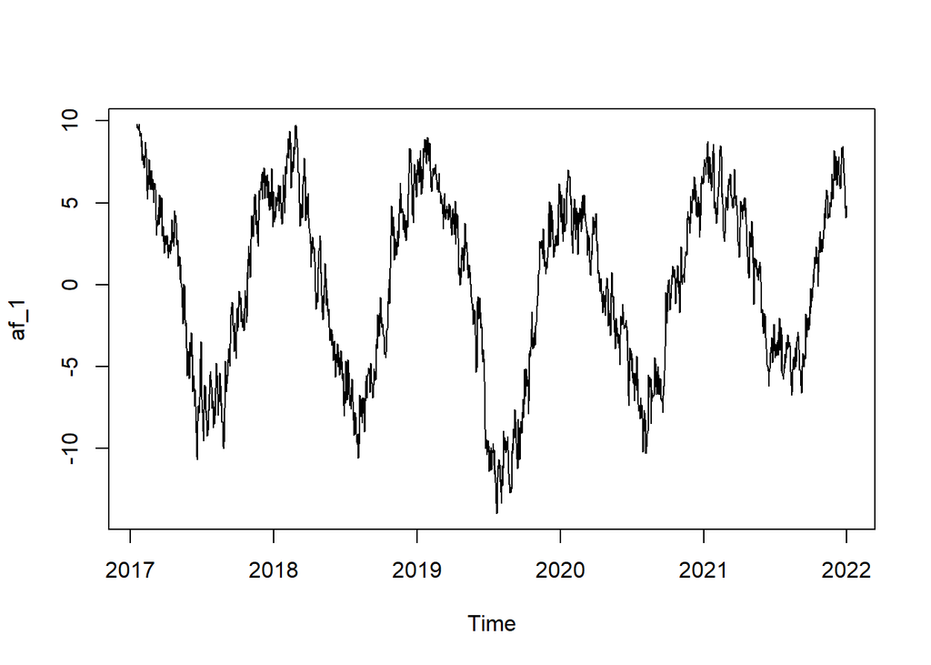

```r
af_1<-ts(acp$li[,1], start =c(2017,19),frequency = 365 )
af_11 <- decompose(af_1)
plot(af_1)
```

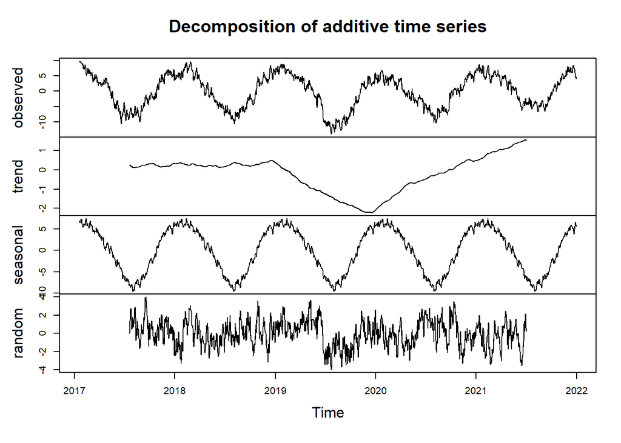

```r
plot(af_11)
```

La série issue de la composante principale 1 présente un aspect saisonnier, avec une tendance globalement stable en 2017-2018, décroissante en 2019, puis à nouveau croissante par la suite. On observe un phénomène particulier en 2019, qui semble avoir perturbé la dynamique des variables liées à la température et à la profondeur de la nappe phréatique.

##### Pour l’axe factoriel 2

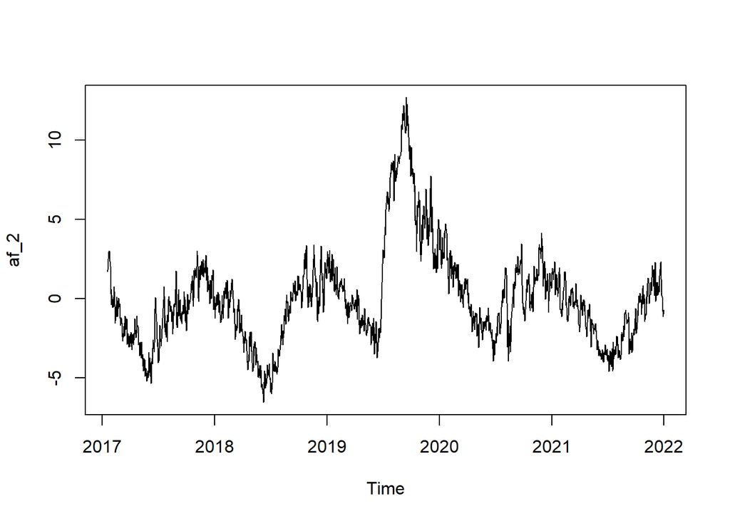

```r
af_2<-ts(acp$li[,2], start =c(2017,19),frequency = 365 )
af_22 <- decompose(af_2)
plot(af_2)
```

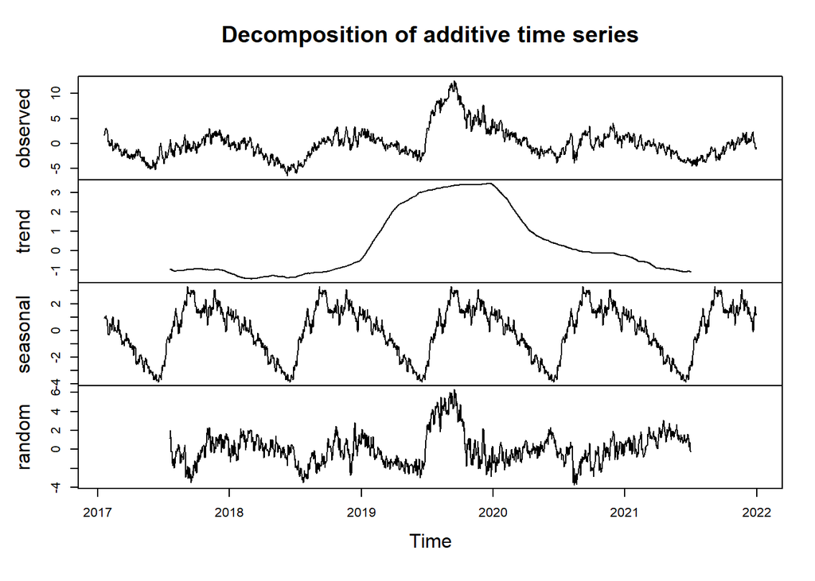

```r
plot(af_22)
```

La série observée sur la composante 2 présente des valeurs plus faibles pendant l’été, ce qui correspond aux variables liées à l’hydrologie. On observe une hausse de la tendance en 2019, qui commence ensuite à revenir à la normale à partir de 2020. Le phénomène observé sur les autres composantes semble également avoir affecté celle-ci, mais son effet paraît plustemporaire.

##### Pour l’axe factoriel 3

-Téndance et saisonnalité

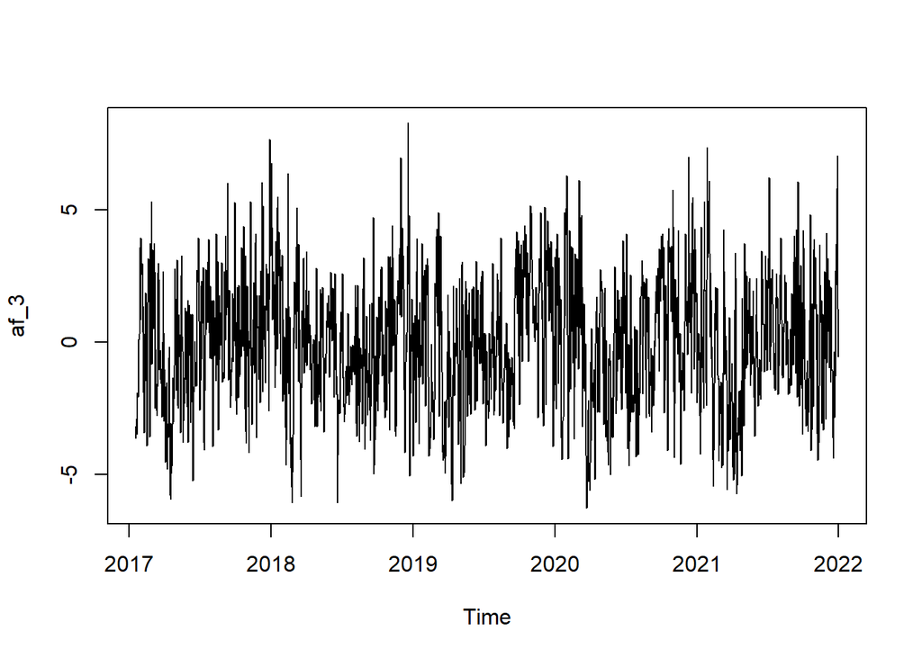

```r
af_3<-ts(acp$li[,3], start =c(2017,19),frequency = 365 )
af_33 <- decompose(af_3)
plot(af_3)
```

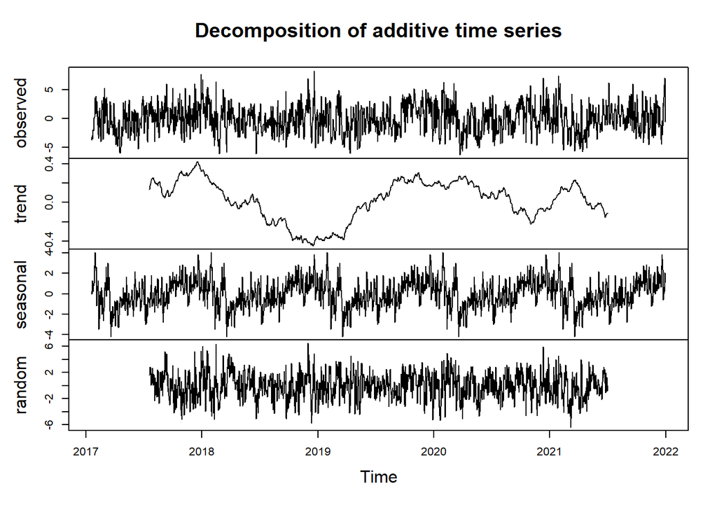

```r
plot(af_33)
```

##### Pour l’axe factoriel 4

-Tendance et saisonnalité

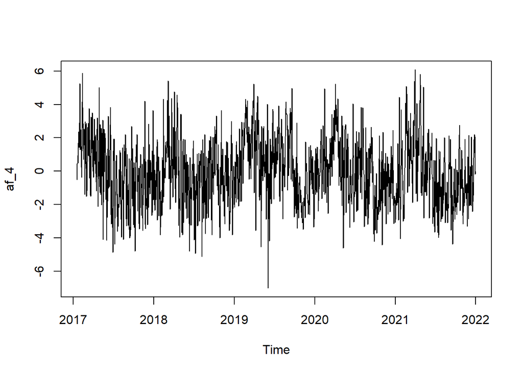

```r
af_4<-ts(acp$li[,4], start =c(2017,19),frequency = 365 )
af_44 <- decompose(af_4)
plot(af_4)
```

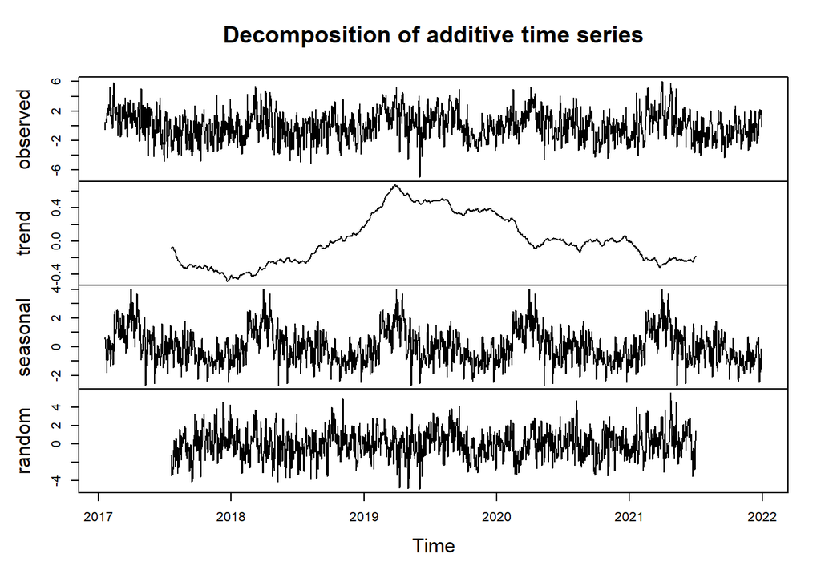

```r
plot(af_44)
```